# Class 3 Models

16/03, 2022

## Models

## What is a model?

- A model is a simplified version of reality that allows us to make inferences or predictions about a population
- A model is an adequate summary of reality
- A model is a simplification or approximation to reality and therefore will not reflect all of reality (Burnham and Anderson)
- All models are wrong, some are useful (George Box)

## Let’s see an example

- ¿How much \(CO_2\) do plants capture?

| Plant | Type | Treatment | conc | uptake |
| --- | --- | --- | --- | --- |
| Qn1 | Quebec | nonchilled | 95 | 16.0 |
| Qn1 | Quebec | nonchilled | 175 | 30.4 |
| Qn1 | Quebec | nonchilled | 250 | 34.8 |
| Qn1 | Quebec | nonchilled | 350 | 37.2 |
| Qn1 | Quebec | nonchilled | 500 | 35.3 |
| Qn1 | Quebec | nonchilled | 675 | 39.2 |
| Qn1 | Quebec | nonchilled | 1000 | 39.7 |
| Qn2 | Quebec | nonchilled | 95 | 13.6 |
| Qn2 | Quebec | nonchilled | 175 | 27.3 |
| Qn2 | Quebec | nonchilled | 250 | 37.1 |
| Qn2 | Quebec | nonchilled | 350 | 41.8 |
| Qn2 | Quebec | nonchilled | 500 | 40.6 |
| Qn2 | Quebec | nonchilled | 675 | 41.4 |
| Qn2 | Quebec | nonchilled | 1000 | 44.3 |
| Qn3 | Quebec | nonchilled | 95 | 16.2 |
| Qn3 | Quebec | nonchilled | 175 | 32.4 |
| Qn3 | Quebec | nonchilled | 250 | 40.3 |
| Qn3 | Quebec | nonchilled | 350 | 42.1 |
| Qn3 | Quebec | nonchilled | 500 | 42.9 |
| Qn3 | Quebec | nonchilled | 675 | 43.9 |
| Qn3 | Quebec | nonchilled | 1000 | 45.5 |
| Qc1 | Quebec | chilled | 95 | 14.2 |
| Qc1 | Quebec | chilled | 175 | 24.1 |
| Qc1 | Quebec | chilled | 250 | 30.3 |
| Qc1 | Quebec | chilled | 350 | 34.6 |
| Qc1 | Quebec | chilled | 500 | 32.5 |
| Qc1 | Quebec | chilled | 675 | 35.4 |
| Qc1 | Quebec | chilled | 1000 | 38.7 |
| Qc2 | Quebec | chilled | 95 | 9.3 |
| Qc2 | Quebec | chilled | 175 | 27.3 |

[output cut: 54 more lines]

## ¿Is it the subspecies?

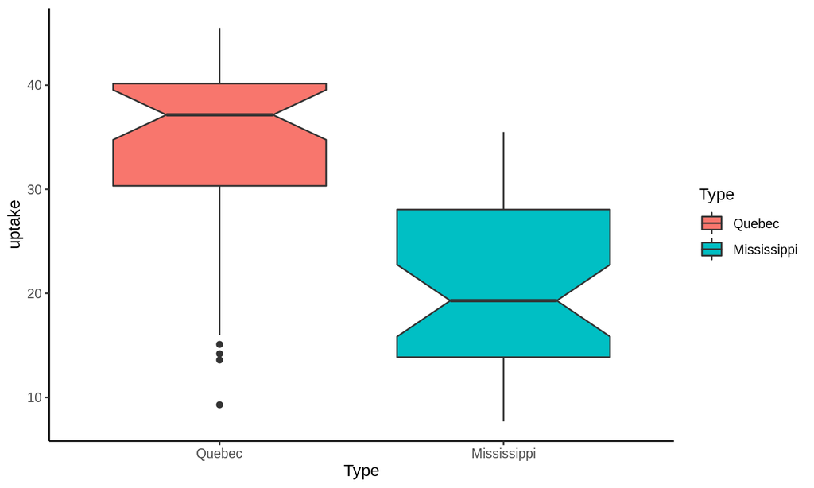

```r
ggplot(CO2, aes(x = Type, y = uptake)) + geom_boxplot(aes(fill = Type),
    notch = TRUE) + theme_classic()
```

## ¿Is it the treatment?

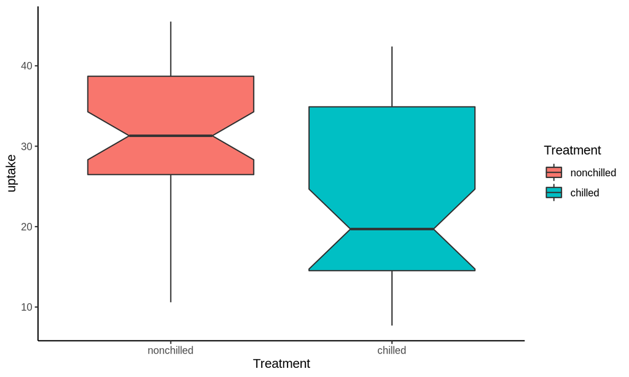

```r
ggplot(CO2, aes(x = Treatment, y = uptake)) + geom_boxplot(aes(fill = Treatment),
    notch = TRUE) + theme_classic()
```

## ¿Is it the concentration?

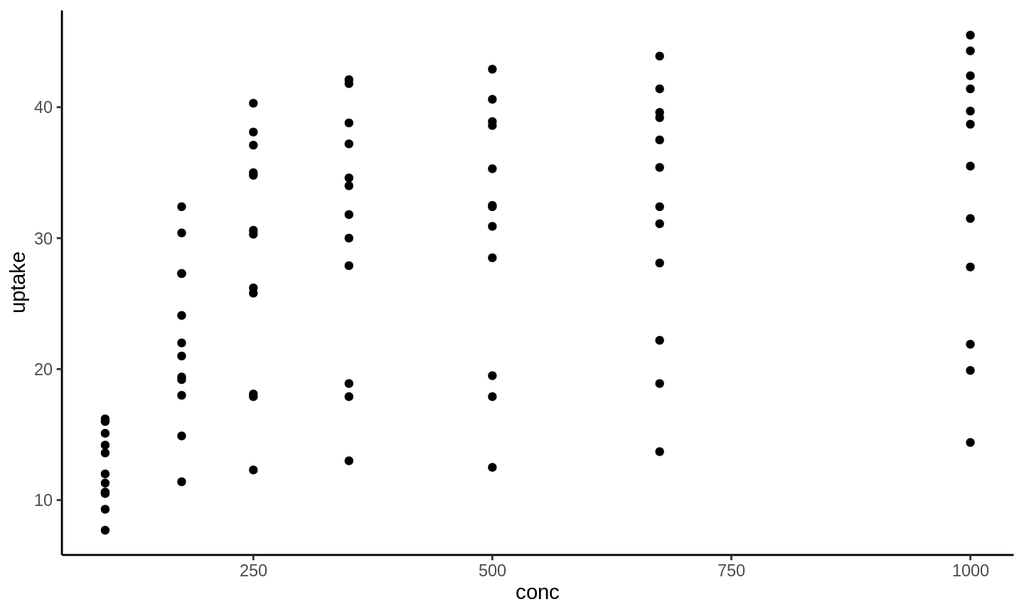

```r
ggplot(CO2, aes(x = conc, y = uptake)) + geom_point() +
    theme_classic()
```

## ¿How do we determine this?

## Model formulation

```r
some_function(Y ~ X1 + X2 + ... + Xn, data = data.frame)
```

- **Y:** Response variable (\(CO_2\) Uptake)
- **`~`:** Explained by
- **\(X_n\):** Explainatory variable n (Subespecies, treatment, etc.)
- **data.frame:** data base (CO2)
- **some_function:** The model to test (our simplification of reality)

## Some models in R

| Modelos | Funcion |
| --- | --- |
| t-test | t.test() |
| ANOVA | aov() |
| Linear model | lm() |
| Generalized linear model | glm() |
| Generalized aditive model | gam() |
| non-linear model | nls() |
| Mixed effect models | lmer() |
| Boosted regression trees | gbm() |

## ¿Which one do we use to study the plant?

```r
Fit1 <- lm(uptake ~ Type, data = CO2)
```

- For this exercise we will start by using a simple linear model
- Equivalent to an ANOVA

## Using broom to get more out of your model (glance)

- To see general data of the model

```r
library(broom)
glance(Fit1)
```

| r.squared | adj.r.squared | sigma | statistic | p.value | df | logLik | AIC | BIC | deviance | df.residual | nobs |
| --- | --- | --- | --- | --- | --- | --- | --- | --- | --- | --- | --- |
| 0.35 | 0.34 | 8.79 | 43.52 | 0 | 1 | -300.8 | 607.6 | 614.89 | 6341.44 | 82 | 84 |

## Using broom to get more out of your model (tidy)

- To see model parameters

```r
tidy(Fit1)
```

| term | estimate | std.error | statistic | p.value |
| --- | --- | --- | --- | --- |
| (Intercept) | 33.54286 | 1.356945 | 24.719384 | 0 |
| TypeMississippi | -12.65952 | 1.919011 | -6.596901 | 0 |

## Using broom to get more out of your model (augment)

- To view model predictions and residuals

```r
augment(Fit1)
```

| uptake | Type | .fitted | .resid | .hat | .sigma | .cooksd | .std.resid |
| --- | --- | --- | --- | --- | --- | --- | --- |
| 16.0 | Quebec | 33.54286 | -17.5428571 | 0.0238095 | 8.625388 | 0.0497139 | -2.0190449 |
| 30.4 | Quebec | 33.54286 | -3.1428571 | 0.0238095 | 8.841068 | 0.0015956 | -0.3617181 |
| 34.8 | Quebec | 33.54286 | 1.2571429 | 0.0238095 | 8.847000 | 0.0002553 | 0.1446873 |
| 37.2 | Quebec | 33.54286 | 3.6571429 | 0.0238095 | 8.838566 | 0.0021605 | 0.4209084 |
| 35.3 | Quebec | 33.54286 | 1.7571429 | 0.0238095 | 8.845923 | 0.0004988 | 0.2022333 |
| 39.2 | Quebec | 33.54286 | 5.6571429 | 0.0238095 | 8.825228 | 0.0051698 | 0.6510927 |
| 39.7 | Quebec | 33.54286 | 6.1571429 | 0.0238095 | 8.820995 | 0.0061240 | 0.7086387 |
| 13.6 | Quebec | 33.54286 | -19.9428571 | 0.0238095 | 8.559179 | 0.0642469 | -2.2952661 |
| 27.3 | Quebec | 33.54286 | -6.2428571 | 0.0238095 | 8.820233 | 0.0062957 | -0.7185038 |
| 37.1 | Quebec | 33.54286 | 3.5571429 | 0.0238095 | 8.839082 | 0.0020440 | 0.4093992 |
| 41.8 | Quebec | 33.54286 | 8.2571429 | 0.0238095 | 8.799269 | 0.0110138 | 0.9503322 |
| 40.6 | Quebec | 33.54286 | 7.0571429 | 0.0238095 | 8.812465 | 0.0080452 | 0.8122217 |
| 41.4 | Quebec | 33.54286 | 7.8571429 | 0.0238095 | 8.803900 | 0.0099726 | 0.9042954 |
| 44.3 | Quebec | 33.54286 | 10.7571429 | 0.0238095 | 8.765042 | 0.0186927 | 1.2380626 |
| 16.2 | Quebec | 33.54286 | -17.3428571 | 0.0238095 | 8.630502 | 0.0485869 | -1.9960265 |
| 32.4 | Quebec | 33.54286 | -1.1428571 | 0.0238095 | 8.847196 | 0.0002110 | -0.1315339 |
| 40.3 | Quebec | 33.54286 | 6.7571429 | 0.0238095 | 8.815439 | 0.0073757 | 0.7776940 |
| 42.1 | Quebec | 33.54286 | 8.5571429 | 0.0238095 | 8.795643 | 0.0118286 | 0.9848599 |
| 42.9 | Quebec | 33.54286 | 9.3571429 | 0.0238095 | 8.785334 | 0.0141437 | 1.0769336 |
| 43.9 | Quebec | 33.54286 | 10.3571429 | 0.0238095 | 8.771133 | 0.0173284 | 1.1920257 |
| 45.5 | Quebec | 33.54286 | 11.9571429 | 0.0238095 | 8.745356 | 0.0230958 | 1.3761731 |
| 14.2 | Quebec | 33.54286 | -19.3428571 | 0.0238095 | 8.576576 | 0.0604392 | -2.2262108 |
| 24.1 | Quebec | 33.54286 | -9.4428571 | 0.0238095 | 8.784174 | 0.0144040 | -1.0867986 |
| 30.3 | Quebec | 33.54286 | -3.2428571 | 0.0238095 | 8.840611 | 0.0016988 | -0.3732274 |
| 34.6 | Quebec | 33.54286 | 1.0571429 | 0.0238095 | 8.847331 | 0.0001805 | 0.1216688 |
| 32.5 | Quebec | 33.54286 | -1.0428571 | 0.0238095 | 8.847352 | 0.0001757 | -0.1200247 |
| 35.4 | Quebec | 33.54286 | 1.8571429 | 0.0238095 | 8.845664 | 0.0005571 | 0.2137425 |
| 38.7 | Quebec | 33.54286 | 5.1571429 | 0.0238095 | 8.829102 | 0.0042963 | 0.5935466 |
| 9.3 | Quebec | 33.54286 | -24.2428571 | 0.0238095 | 8.417641 | 0.0949391 | -2.7901623 |
| 27.3 | Quebec | 33.54286 | -6.2428571 | 0.0238095 | 8.820233 | 0.0062957 | -0.7185038 |

[output cut: 54 more lines]

## Model Selection

- Based on information criteria
- We will work with AIC
- \(K\) number of parameters
- \(\ln{(\hat{L})}\) fit, more positive better, more negative is bad

\[AIC = 2 K - 2 \ln{(\hat{L})}\]

## Candidate models

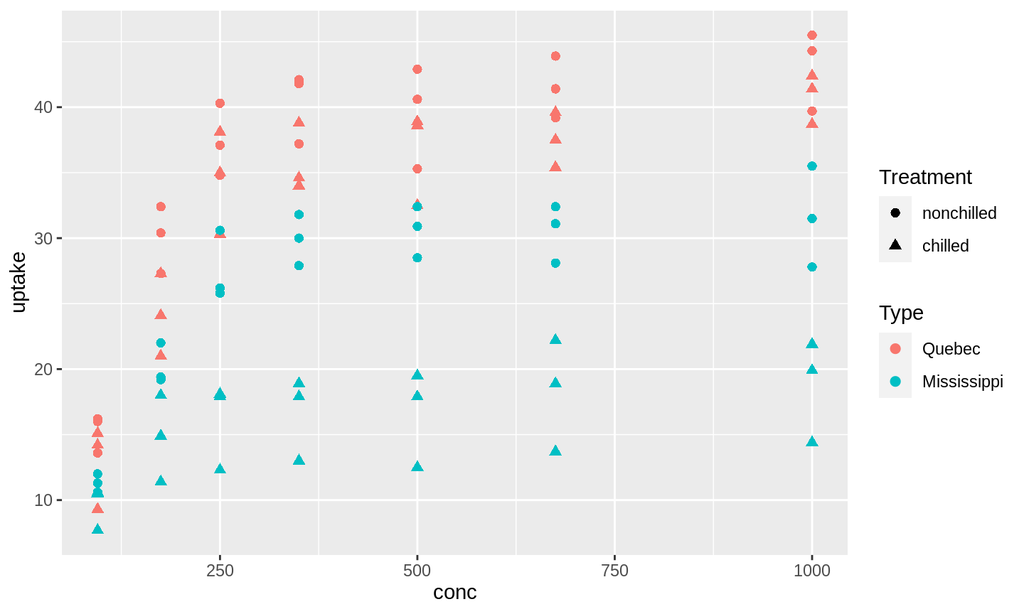

## Candidate models

```r
Fit1 <- lm(uptake ~ Type, data = CO2)
Fit2 <- lm(uptake ~ Treatment, data = CO2)
Fit3 <- lm(uptake ~ conc, data = CO2)
Fit4 <- lm(uptake ~ Type + Treatment + conc, data = CO2)
Fit5 <- lm(uptake ~ Type + conc + I(log(conc)), data = CO2)
Fit6 <- lm(uptake ~ Type:Treatment + conc + I(log(conc)),
    data = CO2)
```

## Interpreting models

## Model 1

- uptake ~ Type

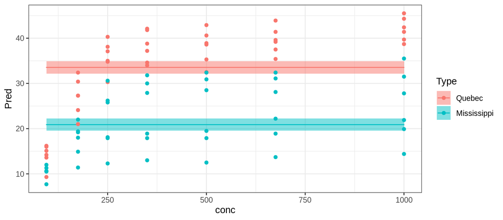

\[ \operatorname{\widehat{uptake}} = 33.54 - 12.66(\operatorname{Type}_{\operatorname{Mississippi}}) \]

## Model 2

- uptake ~ Treatment

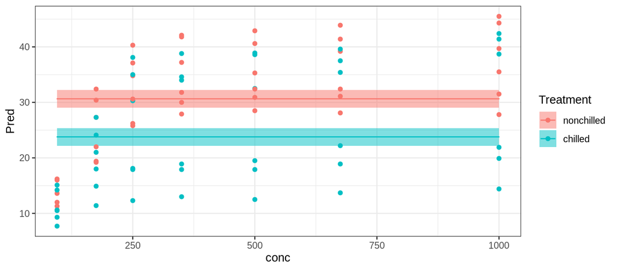

\[ \operatorname{\widehat{uptake}} = 30.64 - 6.86(\operatorname{Treatment}_{\operatorname{chilled}}) \]

## Modelo 3

- uptake ~ conc

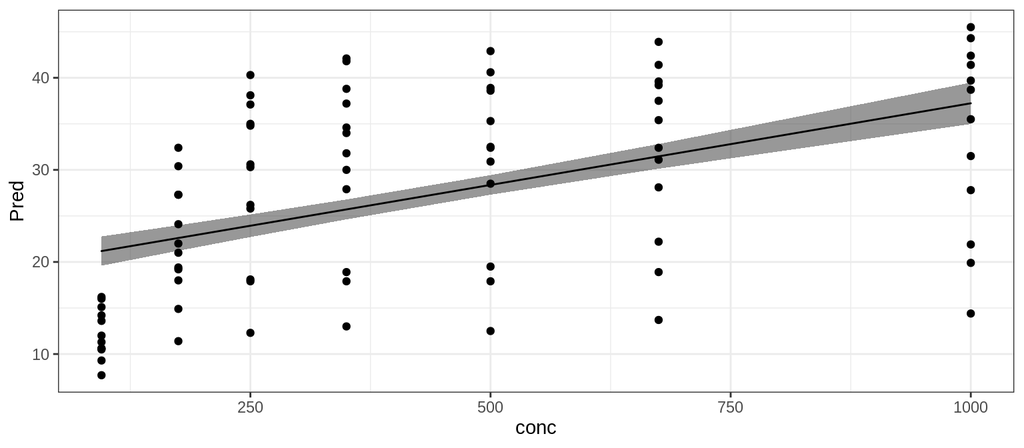

\[ \operatorname{\widehat{uptake}} = 19.5 + 0.02(\operatorname{conc}) \]

## Modelo 4

- uptake ~ Type + Treatment + conc

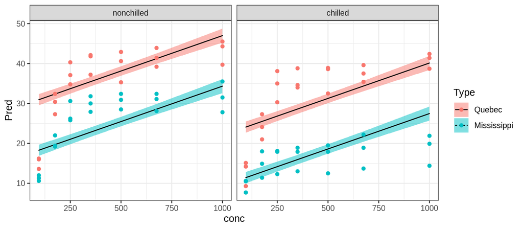

\[ \begin{aligned} \operatorname{\widehat{uptake}} &= 29.26 - 12.66(\operatorname{Type}_{\operatorname{Mississippi}})\ - \\ &\quad 6.86(\operatorname{Treatment}_{\operatorname{chilled}}) + 0.02(\operatorname{conc}) \end{aligned} \]

## Modelo 5

- uptake ~ Type + conc + I(log(conc))

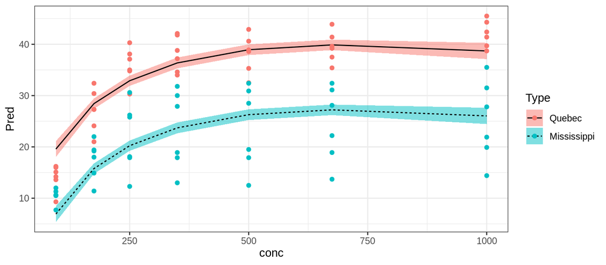

\[ \operatorname{\widehat{uptake}} = -59.04 - 12.66(\operatorname{Type}_{\operatorname{Mississippi}}) - 0.03(\operatorname{conc}) + 17.79(\operatorname{\log(conc)}) \]

## Model 6

- uptake ~ Type:Treatment + conc + I(log(conc))

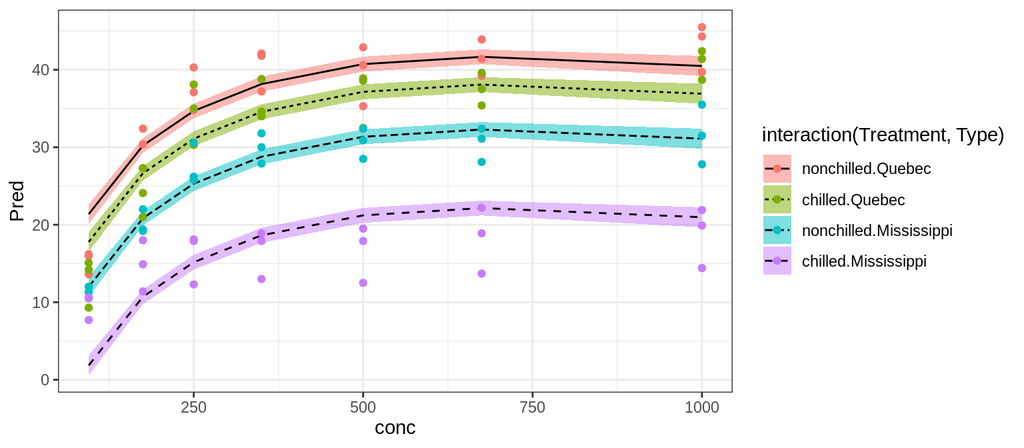

## Seleccion de modelos

## Selección de modelos con broom

```r
Model1 <- glance(Fit1) %>%
    dplyr::select(r.squared, AIC) %>%
    mutate(Model = "Fit1")
Model2 <- glance(Fit2) %>%
    dplyr::select(r.squared, AIC) %>%
    mutate(Model = "Fit2")
Model3 <- glance(Fit3) %>%
    dplyr::select(r.squared, AIC) %>%
    mutate(Model = "Fit3")
Model4 <- glance(Fit4) %>%
    dplyr::select(r.squared, AIC) %>%
    mutate(Model = "Fit4")
Model5 <- glance(Fit5) %>%
    dplyr::select(r.squared, AIC) %>%
    mutate(Model = "Fit5")
Model6 <- glance(Fit6) %>%
    dplyr::select(r.squared, AIC) %>%
    mutate(Model = "Fit6")
Models <- bind_rows(Model1, Model2, Model3, Model4,
    Model5, Model6) %>%
    arrange(AIC) %>%
    mutate(DeltaAIC = AIC - min(AIC))
```

## Model selection with broom

| r.squared | AIC | Model | DeltaAIC |
| --- | --- | --- | --- |
| 0.8738773 | 477.4415 | Fit6 | 0.00000 |
| 0.7488287 | 531.3074 | Fit5 | 53.86593 |
| 0.6839043 | 550.6198 | Fit4 | 73.17834 |
| 0.3467130 | 607.6014 | Fit1 | 130.15996 |
| 0.2353971 | 620.8180 | Fit3 | 143.37653 |
| 0.1017943 | 634.3456 | Fit2 | 156.90410 |

## Any other ideas?

## Individuals

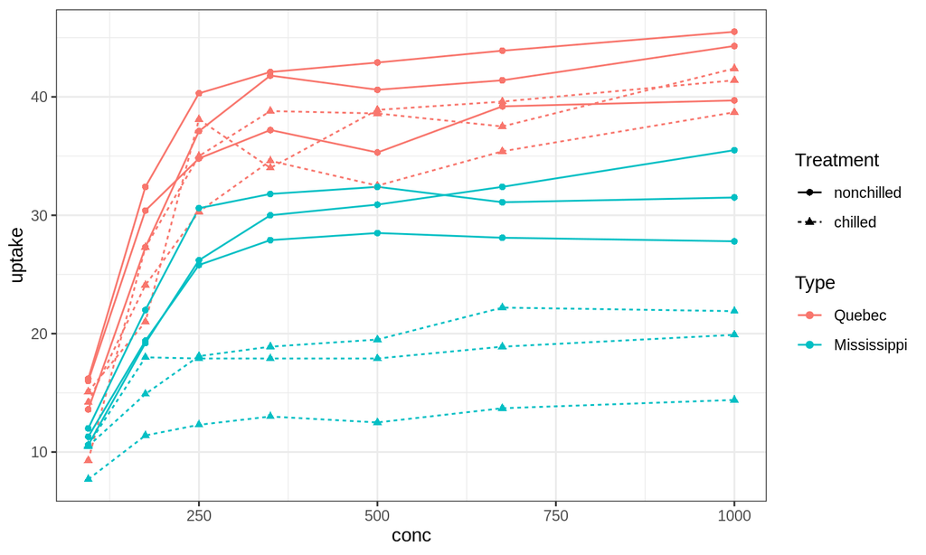

## Mixed effect models

```r
library(lme4)

Fit7 <- lmer(uptake ~ Type:Treatment + conc + I(log(conc)) +
    (1 | Plant), CO2)
```

| loglik | aic | df.residual | r2.conditional | r2.marginal | icc | rmse |
| --- | --- | --- | --- | --- | --- | --- |
| -230.7054 | 477.4108 | 76 | 0.8867725 | 0.8604275 | 0.1887554 | 3.419775 |